# Microphone Basics

## Your Microphone

The microphone in your kit is known as an [electret microphone](https://en.wikipedia.org/wiki/Electret_microphone). An electret is a dielectric material that possesses a permanent or semipermanent electric polarity, analogous to a permanent magnet. The key component of the microphone is this diaphragm that when acoustic waves strike it, it produces a voltage output. This voltage caused by the deflection of the diaphragm may then be measured by the Arduino. The microphone in your kit was purchased from [SparkFun](https://www.sparkfun.com/) found [here](https://www.sparkfun.com/products/8635). From the [datasheet](https://cdn.sparkfun.com/datasheets/Sensors/Sound/CEM-C9745JAD462P2.54R.pdf), it may seen that the microphone has an operating voltage range from $ 1 VDC $ to $ 10 VDC $, a maximum current draw of $ 0.5 mA $, and responses frequencies in the range of $ 100 $ to $ 10,000 Hz $. The microphone anatomy is shown below in Figure 1 comes from the datasheet as well.

Figure 1: Microphone Diagram

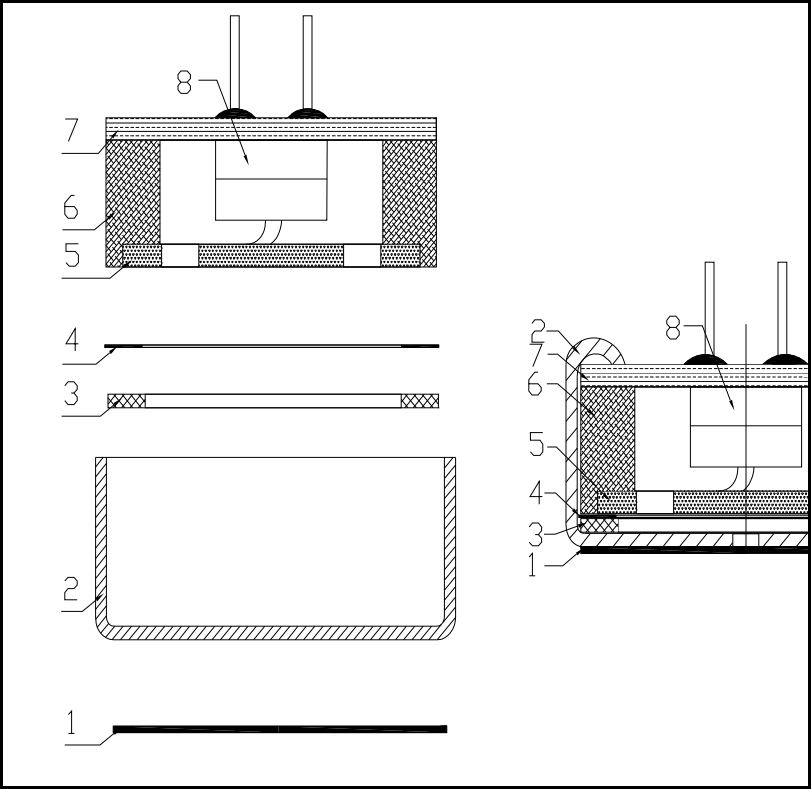

It should be noted that electret microphones do have a polarity. Figure 2 shows a diagram (taken from the datasheet) of the microphone from your kit.

Figure 2: Microphone Diagram

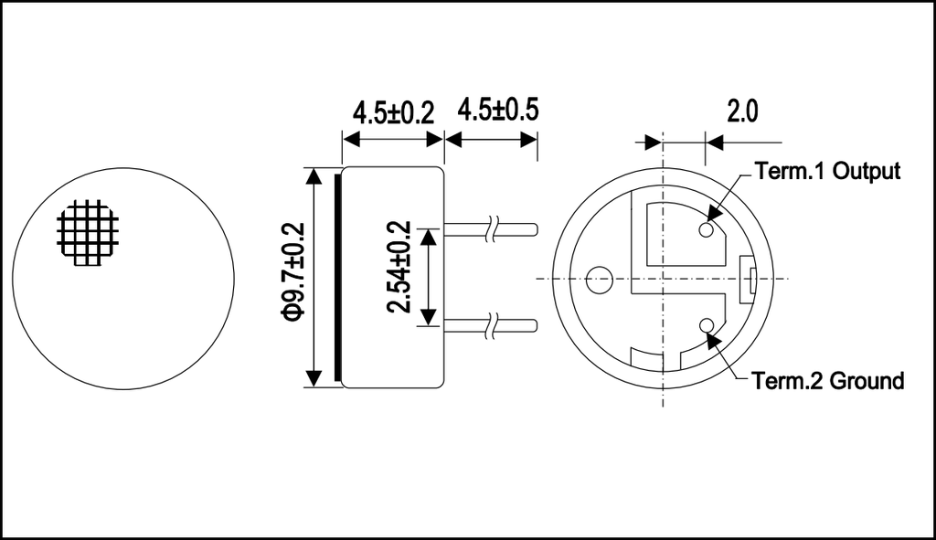

It may be seen that terminal 2 is the ground pin. The easiest way to identify this pin on the actual device is to notice the pad surrounding each pin on the microphone. The pin that has the pad that connects to the microphone's outer casing is the ground pin. This connection is shown in the diagram in Figure 2. The other terminal has a pad that is isolated from everything else. It looks like an island. Whenever implementing the microphone in a circuit, be sure to get the correct orientation of the pins; otherwise, it will not work correctly.